# MEDBORGERNOTAT: Oppskrift

**MEDBORGERNOTAT**

## Ei innføring i koding av politiske hjartesaker i Norsk medborgerpanel

Ingrid Kvåle Faleide  
Ingrid.Faleide@uib.no

Soran Hajo Dahl  
Soran.Dahl@uib.no

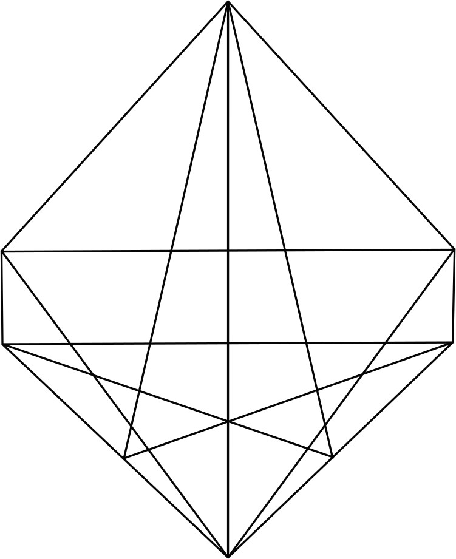

Universitetet i Bergen  
Våren 2021

**Heilt sidan første runde som var i felt hausten 2013, har respondentane i Norsk medborgerpanel regelmessig fått spørsmål om dei politiske hjartesakene sine. Dette materialet vil Bergens Tidende nytte i saker knytte til Stortingsvalet denne hausten. Det er då hjartesak nr. 1 som er i fokus. I dette notatet gir vi ei innføring i korleis hjartesakene vert koda. Dette er heilt vesentleg for korleis ein skal forstå data, og i alle fall naudsynt å lese når ein skal bruke data sjølv.**

Spørsmålet har no vore med i 13 av dei 21 rundane vi har gjennomført av Norsk medborgerpanel og har denne ordlyden:

> Hva er de viktigste politiske sakene eller saksfeltene for deg personlig? Vennligst list de tre viktigste sakene der 1 er den viktigste, 2 er den nest viktigste og 3 er den tredje viktigste saken.

Respondentane kan så skrive akkurat det dei vil - dette vert kalla eit ope spørsmål. Fordelen med å la hjartesak-spørsmålet vere ope, er at vi kan oppdage endringar i kva saker som er viktige til ei bestemt tid. Der er ei rekkje døme på saker som har dukka opp gjennom åra som svar på dette spørsmålet, og dei ville vi elles ikkje ha fanga opp dersom spørsmålet berre hadde hatt lukka svaralternativ. Ulempa med opne spørsmål er sjølvsagt at det krevst ein stor kodejobb for å kunne nytte dataa som kjem fram.

Dei ferdig koda dataa er tilgjengelege for alle. I det koda materialet er kvar respondent sine svar gjort om til ein av 166 kodar. Desse 166 underkategoriane fordeler seg på 24 hovudkategoriar. Om ein ønskjer å nytte seg av dei ferdig koda dataa er det ei rekkje ting å vere obs på. Det gjer vi nærare greie for under “Viktige merknader”. Om du ønskjer å sjå nærare på dei opphavelege svara til respondentane for å studere spesielle tema eller sjå etter andre mønster enn dei vi kodar etter, er det mogeleg å skaffe seg slik tilgang. Dette må skje gjennom DIGSSCORE sin digitale leiar.

Før vi gjer nærare greie for prinsippa som blir følgt i kodinga tek vi ein kikk på dataa.

#### Slik vert dataa

Vi begynner med å sjå på fordelinga av hovudkategoriane i ein runde. Data i figur 1 er frå første runde av Norsk medborgerpanel som var i felt hausten 2013. Om du held musepeikaren over søylene i figuren ser du kor mange av dei 4.166 respondentane som skreiv noko som vart koda innanfor kvar av desse. Helse var den desidert mest brukte kategorien i runde 1: Heile 815 av 4.166 svar hamna innanfor denne hovudkategorien. Den nest-mest brukte kategorien i runde 1 var utdanning, med 545 svar. Etter utdanning føl miljø og økonomi med høvesvis 419 og 365 svar.

**Figur 1: Søylediagram av politisk hjartesak nr. 1** Data er ikkje vekta og viser kor mange svar som har blitt manuelt koda innanfor kvar hovudkategori. *Kjelde:* Norsk medborgerpanel runde 1, haust 2013. N = 4.166.

[interactive chart not shown]

Figur 2 viser utviklinga i seks av dei mest nemnde hjartesakene frå 2013-2021. Vi ser at “Helse” gjennomgåande er den saken som flest er opptekne av i perioden. I frå 2017 begynner “Miljø” å auke, og i januar 2020 blir for første gong i Norsk medborgerpanel si historie ein anna kategori nemnt like mykje som “Helse”. Tilbakegangen i både “Helse” og “Miljø” i juni 2020 blir forklart av auke i mindre kategoriar som ikkje har plass i denne grafen. I juni 2020 var veldig mange fleire opptekne av “Likhet” (Både “Likeverd”, “Diskriminering og anti-rasisme” (Black Lives Matter) og “Likestilling og kvinnekamp”). Vi ser også ein auke i “Arbeid”. I juni 2020 la vi i kodinga til ein ny underkategori under “Helse”: “Covid-19”. I februar 2021 har ikkje overraskande “Helse” blitt nemnt meir enn nokon gong. Vi ser også at “Velferd” har nådd ein ny topp i 2021.

**Figur 2: Linjediagram av politisk hjartesak nr. 1** Data er vekta og viser kor stor del av svara som har blitt manuelt koda innanfor kvar av desse hovudkategoriane. *Kjelde:* Norsk medborgerpanel runde 1-20.

[interactive chart not shown]

#### Slik koder vi data

Det respondentane skriv som svar på hjartesak-spørsmålet er ikkje opent tilgjengeleg fordi respondentane kan skrive identifiserande opplysningar. Svara blir difor omarbeidde og koda av DIGSSCORE sine vitskaplege assistentar. Til dette arbeidet blir det nytta eit kodeskjema utarbeidd av Åsta Dyrnes Nordø. Nordø koda runde 1-2, Runa Falck koda runde 3-10, Ingrid Ovidia Moe Telle koda runde 11 og til dels runde 14, Ingrid Kvåle Faleide koda resten av runde 14 i tillegg til runde 17 og Soran Hajo Dahl koda runde 20. Ein må ta høgde for at ulike vitskaplege assistentar har koda noko ulikt opp gjennom åra. Svar dei har vore usikre på er rapportert i eit samla dokument.

Det varierer i svært stor grad kor mykje respondentane vel å skrive. Dei fleste skriv berre eitt eller nokre frå ord. Desse er som regel enkle å kode. Hovudregelen er at kode blir bestemt av det som blir nemnt først i svaret dersom respondenten er innom fleire tema i eitt svar. Nokre vanlege døme er «helse og sosial» som blir sett under hovudkategorien «helse». «Skatter og avgifter» blir sett på «skatt». Både «skatt» og «avgift» høyrer til under hovudkategorien «økonomi», så det påverkar ikkje analysar av hovudkategoriane. I svar som «helse og sosial» derimot, er det konsekvent skeivheit. Sidan «helse» blir nemnt først blir den plassert under «helse», sjølv om «sosialpolitikk» ligg under hovudkategorien «velferd».

Vi forsøker å vere så spesifikke som mogeleg når vi kodar, i staden for å ta den lette utvegen og berre setje eit svar under hovudkategorien. Likevel er det såpass mange som skriv t.d. berre «Arbeid» eller «Helse», at hovudkategoriane som regel har fleire svar enn nokon av underkategoriane. Ein annan grunn til at hovudkategorien gjerne er størst, er at vi skal unngå for mykje tolking i arbeidet med kodinga. Viss det ikkje er heilt tydeleg at eit svar høyrer til ein av underkategoriane, set vi det som regel under hovudkategorien. Hovudkategorien er ikkje alltid størst, det er t.d. fleire som skriv berre «Skole» enn svar som elles ville hamna under «Utdanning».

Vi unngår også elles å tolke svara til respondentane. Eit døme på dette: *«Retten til liv. Ethvert liv skal bevares og beskyttes»*. Dette svaret blir sett under «Etikk». Det kan dreie seg om abort, men det blir å tolke. Eit anna tema som går att og som kan vere vanskeleg å plassere, er svar som dreier seg om sjukehustilbod. Om det ikkje er heilt tydeleg at eit svar om sjukehusnedlegging handlar om distriktspolitikk blir det sett som «Sjukehus» under «Helse», i staden for ein av kategoriane under «Distrikt/by og land».

Heile kodeskjemaet er summert opp i tabell 1. Det består av 24 hovudkategoriar der alle har mellom 0 og 14 underkategoriar. Talet først i kolonne 2 indikerer tal underkategoriar.

**Tabell 1 Kodeskjema**

[output not shown]

I tillegg til desse brukar vi desse tre kodane:

- 3030 Andre saker
- 9696 Ufullstendige svar / veit ikkje
- 9797 Ubesvart

Det er ofte nemnt i tilleggsdokumentet kodarane noterer i om 3030 er brukt. Dette er typisk generelle svar som *«Generelle levevilkår i Norge»* og *«Ivareta norsk samfunn (…)»*. Denne blir også brukt om det er snakk om Stortings- og regjeringssamansetting eller spesifikke parti, t.d.: *«Få en stabil regjering som kan jobbe effektivt»*, *«Få et skifte av regjering»*, *«Få økt sperregrensen for politiske partier.»* og *«KRF i regjering»*. Lokale saker vert også plassert under 3030.

#### Viktige merknader

**Retning**  
Det er viktig å merke seg at denne kodinga ikkje nyanserer om respondenten er positiv eller negativ til temaet. Ein må passe på å understreke nyansane når ein t.d. seier “så mange er opptekne av omfordeling” - både dei som er for og imot omfordeling ligg her. Det same gjeld t.d. “LGBT-rettigheter” - at LGBT ikkje skal ha rettar er også den viktigaste saka for nokre, og desse hamnar då også under hovudkategorien “Likskap” på same måte som dei som er for LGBT-rettar. Der er eitt unntak frå dette: Oljeutvinning. Her er det ein *for*-kategori under «Næring»: «Oljeproduksjon/utvinning» og ein *i mot*-kategori under «Miljø»: «Reduksjon/stans i oljeutvinning».

**Fleire mogelege plasseringar**  
Det er ikkje alltid heilt opplagt kvar forskjellige tema er plasserte. Svar som *“avvikling av pelsdyroppdrett”* og *“bevaring av pelsindustrien”* er sett som “landbruk” under hovudkategorien “Næring”, og ikkje som “dyrevern og dyrevelferd” under hovudkategorien “Miljø”. Mange svar passar inn i fleire kategoriar. Eitt døme på overlappande kategoriar er «Fornybar energi» under «Miljø» og «Energipolitikk» under «Næring». Svar innan desse kategoriane kan ofte også passe under «Statleg eigarskap» som ligg under «Offentleg og privat sektor». Nokre gonger er ordlyden slik at det passar best å bruke «Norsk suverenitet» under «Utanriks». Slike tilfelle kan nok vere koda ganske ulikt frå runde til runde.